# Отчет по домашней работе №3

```r
# install.packages("pacman")
pacman::p_load(ISwR, ggplot2, dplyr, nortest, car, tidyverse, scales, emmeans, multcomp, multcompView, gtsummary, knitr)
```

1. В пакете ISwR содержится набор данных juul, который содержит концентрации инсулин-подобного фактора роста (igf1) и описательные данные пациентов (sex – пол, age – возраст). Загрузите этот набор данных.

```r
data(juul)
```

```r
kable(head(juul))
```

| age | menarche | sex | igf1 | tanner | testvol |
| --- | --- | --- | --- | --- | --- |
| NA | NA | NA | 90 | NA | NA |
| NA | NA | NA | 88 | NA | NA |
| NA | NA | NA | 164 | NA | NA |
| NA | NA | NA | 166 | NA | NA |
| NA | NA | NA | 131 | NA | NA |
| 0.17 | NA | 1 | 101 | 1 | NA |

```r
str(juul)
```

```
## 'data.frame':    1339 obs. of  6 variables:
##  $ age     : num  NA NA NA NA NA 0.17 0.17 0.17 0.17 0.17 ...
##  $ menarche: int  NA NA NA NA NA NA NA NA NA NA ...
##  $ sex     : num  NA NA NA NA NA 1 1 1 1 1 ...
##  $ igf1    : num  90 88 164 166 131 101 97 106 111 79 ...
##  $ tanner  : int  NA NA NA NA NA 1 1 1 1 1 ...
##  $ testvol : int  NA NA NA NA NA NA NA NA NA NA ...
```

```r
kable(summary(juul))
```

|  | age | menarche | sex | igf1 | tanner | testvol |
| --- | --- | --- | --- | --- | --- | --- |
|  | Min. : 0.170 | Min. :1.000 | Min. :1.000 | Min. : 25.0 | Min. :1.00 | Min. : 1.000 |
|  | 1st Qu.: 9.053 | 1st Qu.:1.000 | 1st Qu.:1.000 | 1st Qu.:202.2 | 1st Qu.:1.00 | 1st Qu.: 1.000 |
|  | Median :12.560 | Median :1.000 | Median :2.000 | Median :313.5 | Median :2.00 | Median : 3.000 |
|  | Mean :15.095 | Mean :1.476 | Mean :1.534 | Mean :340.2 | Mean :2.64 | Mean : 7.896 |
|  | 3rd Qu.:16.855 | 3rd Qu.:2.000 | 3rd Qu.:2.000 | 3rd Qu.:462.8 | 3rd Qu.:5.00 | 3rd Qu.:15.000 |
|  | Max. :83.000 | Max. :2.000 | Max. :2.000 | Max. :915.0 | Max. :5.00 | Max. :30.000 |
|  | NA’s :5 | NA’s :635 | NA’s :5 | NA’s :321 | NA’s :240 | NA’s :859 |

2. Создайте во фрейме новую переменную, содержащую квадратный корень из концентрации инсулин-подобного фактора роста.

```r
juul$sqrt_igf1 <- sqrt(juul$igf1)
kable(tail(juul))
```

|  | age | menarche | sex | igf1 | tanner | testvol | sqrt_igf1 |
| --- | --- | --- | --- | --- | --- | --- | --- |
| 1334 | 58.95 | 2 | 2 | 218 | 5 | NA | 14.76482 |
| 1335 | 60.99 | 2 | 2 | 226 | 5 | NA | 15.03330 |
| 1336 | 62.73 | 2 | 2 | NA | NA | NA | NA |
| 1337 | 65.00 | 2 | 2 | 106 | NA | NA | 10.29563 |
| 1338 | 67.88 | 2 | 2 | 217 | NA | NA | 14.73092 |
| 1339 | 75.12 | 2 | 2 | 135 | NA | NA | 11.61895 |

3. Постройте регрессионную модель зависимости квадратного корня концентрации инсулин-подобного фактора роста от возраста для пациентов старше 25 лет.

```r
juul_over_25 <- subset(juul, age > 25)
fit <- lm(sqrt_igf1 ~ age, data = juul_over_25)
summary(fit)
```

```
##
## Call:
## lm(formula = sqrt_igf1 ~ age, data = juul_over_25)
##
## Residuals:
##     Min      1Q  Median      3Q     Max
## -4.8642 -1.1661  0.1018  0.9450  4.1136
##
## Coefficients:
##             Estimate Std. Error t value Pr(>|t|)
## (Intercept) 18.71025    0.49462  37.828   <2e-16 ***
## age         -0.10533    0.01072  -9.829   <2e-16 ***
## ---
## Signif. codes:  0 '***' 0.001 '**' 0.01 '*' 0.05 '.' 0.1 ' ' 1
##
## Residual standard error: 1.741 on 120 degrees of freedom
##   (4 пропущенных наблюдений удалены)
## Multiple R-squared:  0.446,  Adjusted R-squared:  0.4414
## F-statistic:  96.6 on 1 and 120 DF,  p-value: < 2.2e-16
```

4. Проанализируйте характер распределения остатков регрессионной модели. Постройте гистограмму их распределения, примените три критерия согласия. В комментарии приведите p-значения и сделайте итоговый вывод.

```r
residuals <- residuals(fit)

# 1. Критерий Шапиро-Уилка
shapiro_test <- shapiro.test(residuals)
# 2. Критерий Лиллиефорса
lillie <- lillie.test(residuals)
# 3. Критерий Андерсона-Дарлинга
ad_test <- ad.test(residuals)
```

```r
p_values <- data.frame(
  Test = c("Шапиро-Уилка", "Лиллиефорса", "Андерсона-Дарлинга"),
  `p-value` = c(shapiro_test$p.value, lillie$p.value, ad_test$p.value)
)
kable(p_values, col.names = c("Критерий", "p-value"))
```

| Критерий | p-value |
| --- | --- |
| Шапиро-Уилка | 0.5945936 |
| Лиллиефорса | 0.7321537 |
| Андерсона-Дарлинга | 0.6734449 |

Поскольку все три теста показывают p > 0.05 (0.59, 0.73 и 0.67 соответственно), **распределение остатков можно считать нормальным**.

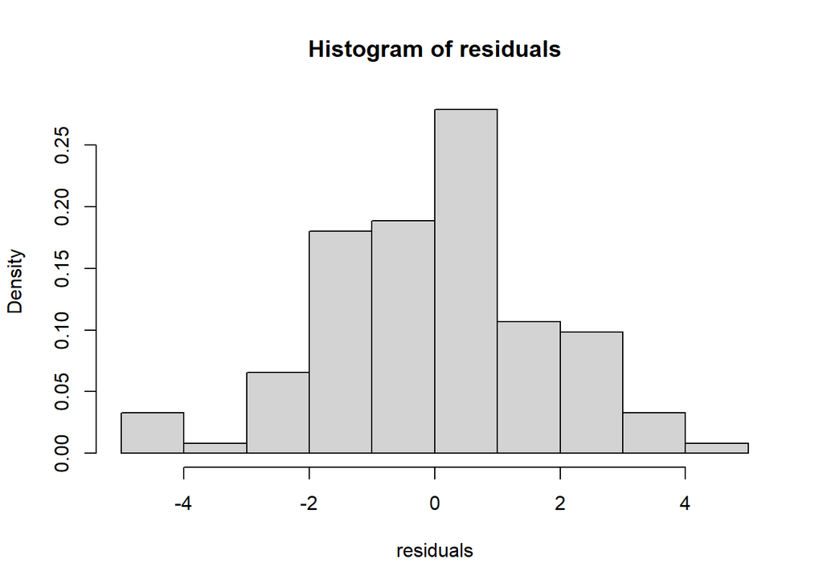

```r
# Гистограмма остатков
hist(residuals, freq = FALSE)
```

Наблюдается **распределение, близкое к нормальному**.

5. Проведите анализ гомоскедастичности регрессионной модели. В комментарии приведите название процедуры, p-значение и сделайте вывод.

Тест Бройша-Пагана:

```r
ncvRes <- ncvTest(fit)
ncvRes
```

```
## Non-constant Variance Score Test
## Variance formula: ~ fitted.values
## Chisquare = 0.8506106, Df = 1, p = 0.35638
```

```r
bp_p_value <- ncvRes$p
cat("p-значение теста Бройша-Пагана:", bp_p_value, "\n")
```

```
## p-значение теста Бройша-Пагана: 0.3563796
```

```r
if (bp_p_value > 0.05) {
  cat("Гомоскедастичность подтверждена (p > 0.05). Модель удовлетворяет условию равенства дисперсий остатков.\n")
} else {
  cat("Гетероскедастичность обнаружена (p < 0.05). Модель не удовлетворяет условию равенства дисперсий остатков.\n")
}
```

```
## Гомоскедастичность подтверждена (p > 0.05). Модель удовлетворяет условию равенства дисперсий остатков.
```

6. Проведите анализ статистической значимости коэффициентов регрессионной модели. В комментарии приведите название процедуры, p-значение и сделайте вывод.

Для каждого коэффициента модели проводится t-тест на статистическую значимость. Интерпретация:

p-value для обоих коэффициентов (интерсепта и переменной `age`) < 2e-16, что намного меньше уровня значимости 0.05: оба коэффициента (интерсепт и возраст) статистически значимы. Это означает, что возраст оказывает значительное влияние на уровень IGF-1 (с учетом проведенной трансформации), и модель линейной регрессии имеет значимые коэффициенты.

7. Как изменится ожидаемое значение переменной отклика в регрессионной модели при увеличении возраста на 5 месяцев?

```r
# Извлекаем коэффициенты из модели
coefficients_model <- coef(fit)
# Коэффициент при переменной age
beta_1 <- coefficients_model['age']
# Рассчитываем изменение ожидаемого значения sqrt_igf1 при увеличении возраста на 5 месяцев
change_in_response <- beta_1 * (5 / 12)

# Выводим результат
cat("Изменение ожидаемого значения sqrt_igf1 при увеличении возраста на 5 месяцев:", change_in_response, "\n")
```

```
## Изменение ожидаемого значения sqrt_igf1 при увеличении возраста на 5 месяцев: -0.04388695
```

8. Каково ожидаемое значение переменной отклика для следующих значений возраста: 41.77, 41.88, 43.84, 46.08, 54.91?

```r
ages <- c(41.77, 41.88, 43.84, 46.08, 54.91)

new_data <- data.frame(age = ages)
prediction <- predict(fit, new_data)

kable(data.frame(age=ages, predicted=prediction))
```

| age | predicted |
| --- | --- |
| 41.77 | 14.31067 |
| 41.88 | 14.29909 |
| 43.84 | 14.09264 |
| 46.08 | 13.85670 |
| 54.91 | 12.92665 |

9. Рассчитайте и приведите в комментарии 95 %-ный доверительный интервал для коэффициента наклона.

```r
conf_intervals <- confint(fit)
kable(conf_intervals['age', ], col.names = c('age'), label = '95%-ный доверительный интервал для коэффициента наклона (age)')
```

|  | age |
| --- | --- |
| 2.5 % | -0.1265467 |
| 97.5 % | -0.0841107 |

Интерпретация:

- Если доверительный интервал не включает 0 (например, если оба конца интервала строго положительные или строго отрицательные), это указывает на статистически значимый эффект возраста на переменную отклика.
- Если доверительный интервал включает 0, это означает, что влияние возраста на переменную отклика может быть статистически незначимым на уровне 95%-ного доверия.

В данном случае оба конца интервала строго отрицательные, значит **есть статистически значимый эффект возраста на переменную отклика**.

10. Постройте диаграмму рассеяния для данных, на основе которых построена анализируемая регрессионная модель. Используйте залитые полупрозрачные круги зеленого цвета. Подпишите оси. Добавьте на график линию регрессии.

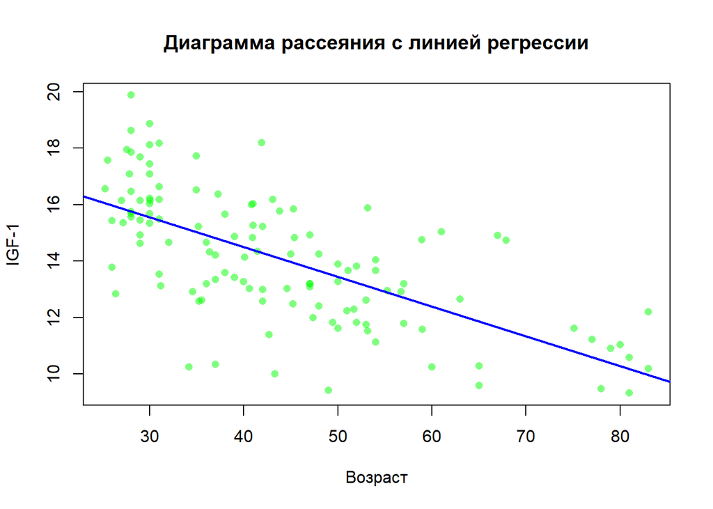

```r
# Построение диаграммы рассеяния
plot(juul_over_25$age, juul_over_25$sqrt_igf1,
     col = rgb(0, 1, 0, 0.5),
     pch = 16,
     xlab = "Возраст",
     ylab = "IGF-1",
     main = "Диаграмма рассеяния с линией регрессии")

# Добавление линии регрессии
abline(fit, col = "blue", lwd = 2)  # Линия регрессии синего цвета
```

11. Добавьте на график доверительные интервалы для положения линии регресии и для прогнозируемых данных. Границы интервалов должны отличаться цветом от линии регрессии и друг от друга.

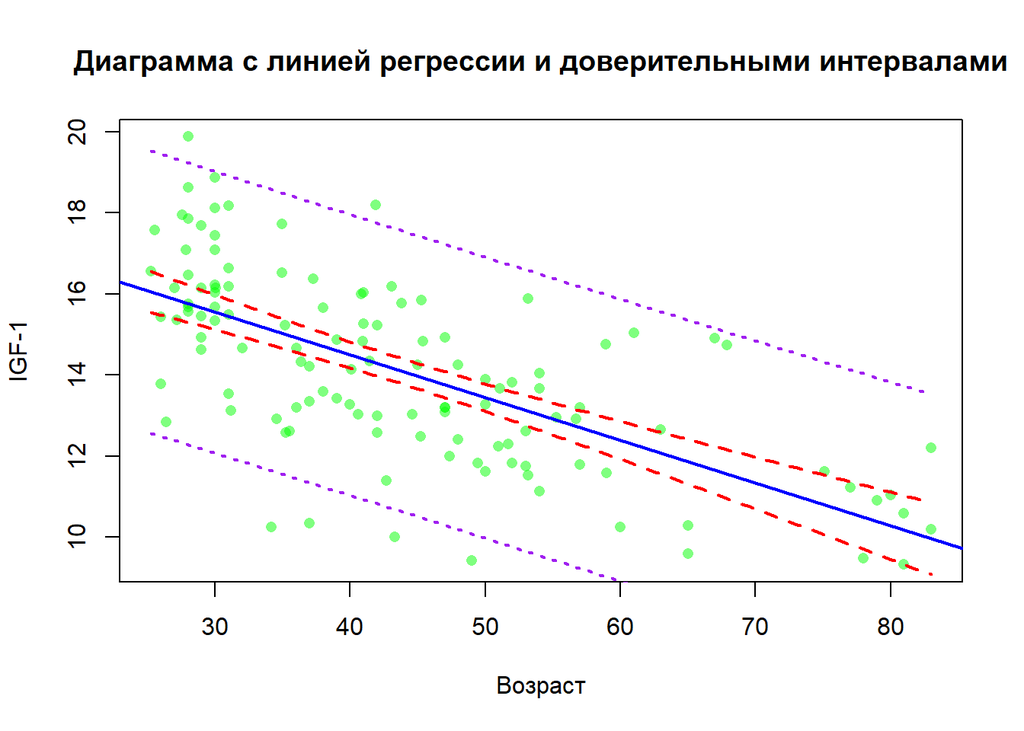

```r
age_range <- data.frame(age = seq(min(juul_over_25$age), max(juul_over_25$age), length.out = 100))
confidence_intervals <- predict(fit, newdata = age_range, interval = "confidence")
prediction_intervals <- predict(fit, newdata = age_range, interval = "prediction")

plot(juul_over_25$age, juul_over_25$sqrt_igf1,
     col = rgb(0, 1, 0, 0.5),  # Полупрозрачный зелёный цвет
     pch = 16,                 # Залитые круги
     xlab = "Возраст",         # Подпись оси X
     ylab = "IGF-1",  # Подпись оси Y
     main = "Диаграмма с линией регрессии и доверительными интервалами")


abline(fit, col = "blue", lwd = 2)  # Линия регрессии

lines(age_range$age, confidence_intervals[, "lwr"], col = "red", lty = 2, lwd = 2)  # Нижняя граница доверительного интервала
lines(age_range$age, confidence_intervals[, "upr"], col = "red", lty = 2, lwd = 2)  # Верхняя граница доверительного интервала

lines(age_range$age, prediction_intervals[, "lwr"], col = "purple", lty = 3, lwd = 2)  # Нижняя граница прогноза
lines(age_range$age, prediction_intervals[, "upr"], col = "purple", lty = 3, lwd = 2)  # Верхняя граница прогноза
```